# Cleaning, EDA, and GitHub

7/18/22

# Quick Reminder: React and Communicate

- All of you have been doing great so far!
- Please keep reacting to those messages and filling out the When2Meet's
- Remember to reach out to me if you need help or something comes up where you need an extension

# Baseball Reference Data Cleaning

- Now we will cover a few ways your data should be formatted and some tips for cleaning

### Export you pandas DataFrame as a .csv file

- This way, you won't need to access your web scraping code every time you want to use the DataFrame
- You can also more easily import your data into new jupyter notebooks

```python
# as always, begin with importing the libraries you will use
import numpy as np
import pandas as pd
```

# Data Cleaning: Export Your DataFrame As a .csv File

```python
relief # this is how your DataFrame should look at the end of the web scraping process
```

|  | Year | Tm | G | GR | GF | Wgr | Lgr | SVOpp | SV | BSv | ... | Bhd | Runr | Empt | >3o | <3o | IPmult | 0DR | Out/GR | Pit/GR | Playoff |
| --- | --- | --- | --- | --- | --- | --- | --- | --- | --- | --- | --- | --- | --- | --- | --- | --- | --- | --- | --- | --- | --- |
| 0 | 2000 | Anaheim Angels | 162 | 441 | 157 | 29 | 24 | 68 | 46 | 22 | ... | 201 | 168 | 273 | 169 | 124 | 186 | 95 | 3.8 | 21 | 0 |
| 1 | 2000 | Arizona Diamondbacks | 162 | 390 | 146 | 23 | 24 | 56 | 38 | 18 | ... | 169 | 129 | 261 | 120 | 111 | 140 | 72 | 3.4 | 19 | 0 |
| 2 | 2000 | Atlanta Braves | 162 | 376 | 149 | 19 | 18 | 67 | 53 | 14 | ... | 142 | 112 | 264 | 91 | 101 | 95 | 81 | 3.2 | 18 | 1 |
| 3 | 2000 | Baltimore Orioles | 162 | 396 | 148 | 22 | 21 | 57 | 33 | 24 | ... | 166 | 145 | 251 | 99 | 125 | 119 | 84 | 3.3 | 19 | 0 |
| 4 | 2000 | Boston Red Sox | 162 | 425 | 155 | 29 | 23 | 66 | 46 | 20 | ... | 173 | 137 | 288 | 181 | 91 | 191 | 80 | 4.0 | 21 | 0 |
| ... | ... | ... | ... | ... | ... | ... | ... | ... | ... | ... | ... | ... | ... | ... | ... | ... | ... | ... | ... | ... | ... |
| 655 | 2021 | St. Louis Cardinals | 162 | 557 | 159 | 36 | 25 | 71 | 50 | 21 | ... | 217 | 167 | 390 | 123 | 148 | 155 | 99 | 3.1 | 18 | 1 |
| 656 | 2021 | Tampa Bay Rays | 162 | 531 | 161 | 58 | 32 | 64 | 42 | 22 | ... | 134 | 126 | 405 | 182 | 89 | 198 | 73 | 4.0 | 21 | 1 |
| 657 | 2021 | Texas Rangers | 162 | 507 | 162 | 27 | 31 | 51 | 31 | 20 | ... | 269 | 143 | 364 | 144 | 98 | 162 | 50 | 3.7 | 21 | 0 |
| 658 | 2021 | Toronto Blue Jays | 162 | 537 | 161 | 30 | 31 | 52 | 34 | 18 | ... | 208 | 167 | 370 | 136 | 136 | 167 | 63 | 3.2 | 18 | 0 |
| 659 | 2021 | Washington Nationals | 162 | 569 | 161 | 23 | 42 | 73 | 36 | 37 | ... | 248 | 151 | 418 | 100 | 164 | 113 | 138 | 3.0 | 18 | 0 |

660 rows × 33 columns

# Data Cleaning: Export Your DataFrame As a .csv File

To export your DataFrame as a .csv file, use the `.to_csv()` method on a DataFrame

```python
# It is good practice to hashtag read_csv() and to_csv() commands when you share code files so that
# if someone else opens your file, you don't load things on to their computer they may not want

# relief.to_csv('ReliefPitching.csv', index = False)

# .to_csv('File_Name.csv', index = [Do you want to include the index in your .csv file?])
```

Remember to *not* hastag this when you run it on your own computer or else it won't run

When working in Python and R, I usually set `index = False`. If you don't, when you read the .csv file in, it will show the both the index and the first column of the data frame as the index.

# Data Cleaning: Import Your DataFrame As a .csv File

To import your DataFrame as a .csv file, use the `.read_csv()` in pandas

```python
relief = pd.read_csv('ReliefPitching.csv', float_precision = 'round_trip')
# pandas sacrifices decimal accuracy for speed on .csv file read-in's, so using float_precision = 'round_trip'
# will read in accurate decimals, which is important for our project
```

```python
relief.head()
```

|  | Year | Tm | G | GR | GF | Wgr | Lgr | SVOpp | SV | BSv | ... | Bhd | Runr | Empt | >3o | <3o | IPmult | 0DR | Out/GR | Pit/GR | Playoff |
| --- | --- | --- | --- | --- | --- | --- | --- | --- | --- | --- | --- | --- | --- | --- | --- | --- | --- | --- | --- | --- | --- |
| 0 | 2000 | Anaheim Angels | 162 | 441 | 157 | 29 | 24 | 68 | 46 | 22 | ... | 201 | 168 | 273 | 169 | 124 | 186 | 95 | 3.8 | 21 | 0 |
| 1 | 2000 | Arizona Diamondbacks | 162 | 390 | 146 | 23 | 24 | 56 | 38 | 18 | ... | 169 | 129 | 261 | 120 | 111 | 140 | 72 | 3.4 | 19 | 0 |
| 2 | 2000 | Atlanta Braves | 162 | 376 | 149 | 19 | 18 | 67 | 53 | 14 | ... | 142 | 112 | 264 | 91 | 101 | 95 | 81 | 3.2 | 18 | 1 |
| 3 | 2000 | Baltimore Orioles | 162 | 396 | 148 | 22 | 21 | 57 | 33 | 24 | ... | 166 | 145 | 251 | 99 | 125 | 119 | 84 | 3.3 | 19 | 0 |
| 4 | 2000 | Boston Red Sox | 162 | 425 | 155 | 29 | 23 | 66 | 46 | 20 | ... | 173 | 137 | 288 | 181 | 91 | 191 | 80 | 4.0 | 21 | 0 |

5 rows × 33 columns

# Data Cleaning: Useful Methods

The `.info()` method for DataFrames gives you the data types and count of non-null values in each column

```python
relief.info()
```

```
<class 'pandas.core.frame.DataFrame'>
RangeIndex: 660 entries, 0 to 659
Data columns (total 33 columns):
 #   Column   Non-Null Count  Dtype
---  ------   --------------  -----
 0   Year     660 non-null    int64
 1   Tm       660 non-null    object
 2   G        660 non-null    int64
 3   GR       660 non-null    int64
 4   GF       660 non-null    int64
 5   Wgr      660 non-null    int64
 6   Lgr      660 non-null    int64
 7   SVOpp    660 non-null    int64
 8   SV       660 non-null    int64
 9   BSv      660 non-null    int64
```

[output cut: 25 more lines]

# Data Cleaning: Useful Methods

Here are the things I took away from running the `.info()` method:

- The 16th column, 1stIP, has 0 non-null values -- this probably means I should drop that column
- SV% and IS% are listed as type object (type object means string or mixed data type). From the table on Baseball Reference, I expected these to be numbers, not strings -- this means I should edit these columns

When you do your cleaning, you might encounter these same issues or different ones that will need to be fixed. Keep an eye out and make sure all of your columns are properly and neatly formatted

# Data Cleaning: Useful Methods

Here is a demonstration on how I combatted the two issues I found in my DataFrame

First, I used the `.drop()` method to remove the NaN column. `.drop()` allows you to drop a row or column in a DataFrame.

```python
relief.drop('1stIP', axis = 1, inplace = True)
# drop the 1stIP column, axis = 1 means 1stIP is a column, not a row (rows are axis = 0)
# inplace = True means drop the column on the actual relief DataFrame, not a copy of it
# inplace = True is the same as relief = relief.drop('1stIP', axis = 1)
relief.keys() # as you can see, the 1stIP column is gone (.keys() shows the columns of a DataFrame)
```

```
Index(['Year', 'Tm', 'G', 'GR', 'GF', 'Wgr', 'Lgr', 'SVOpp', 'SV', 'BSv',
       'SV%', 'SVSit', 'Hold', 'IR', 'IS', 'IS%', 'aLI', 'LevHi', 'LevMd',
       'LevLo', 'Ahd', 'Tie', 'Bhd', 'Runr', 'Empt', '>3o', '<3o', 'IPmult',
       '0DR', 'Out/GR', 'Pit/GR', 'Playoff'],
      dtype='object')
```

# Data Cleaning: Useful Methods

Next, I used regular expressions to change the SV% and IS% columns into decimals

```python
relief['SV%'].head()
# now we see the problem, they are formatted as strings because they include a '%' character
```

```
0    68%
1    68%
2    79%
3    58%
4    70%
Name: SV%, dtype: object
```

```python
relief['SV%'].str.extract('(\d+)%').head() # from the string library, use the extract function
# regular expression '(\d+)%' in English:
# the strings should be 1 or more digits, then a % character; give back only digits
```

|  | 0 |
| --- | --- |
| 0 | 68 |
| 1 | 68 |
| 2 | 79 |
| 3 | 58 |
| 4 | 70 |

# Data Cleaning: Useful Methods

```python
relief['SV%'].str.extract('(\d+)%').astype('int').head() # convert those numbers from strings to integers
```

|  | 0 |
| --- | --- |
| 0 | 68 |
| 1 | 68 |
| 2 | 79 |
| 3 | 58 |
| 4 | 70 |

```python
relief['SV%'].str.extract('(\d+)%').astype('int').multiply(1 / 100).head() # divide by 100 to get % as decimals
```

|  | 0 |
| --- | --- |
| 0 | 0.68 |
| 1 | 0.68 |
| 2 | 0.79 |
| 3 | 0.58 |
| 4 | 0.70 |

# Data Cleaning: Useful Methods

```python
relief['SV%'] = relief['SV%'].str.extract('(\d+)%').astype('int') / 100
relief['IS%'] = relief['IS%'].str.extract('(\d+)%').astype('int') / 100
```

```python
relief['IS%'].head()
```

```
0    0.30
1    0.31
2    0.29
3    0.34
4    0.38
Name: IS%, dtype: float64
```

```python
# And the last step to complete the cleaning:
# relief.to_csv('ReliefPitching_CLEAN.csv', index = False)
```

# Preparing Our Data for Visualization

To prepare our data, we should change the Playoff column to a category with Yes and No as the two values to make our graphs treat Playoffs like a categorical variable.

```python
# pd.Series.replace() replaces the values in a series with a different value
pd.Series.replace(relief.Playoff, to_replace = 0, value = 'No', inplace = True)
pd.Series.replace(relief.Playoff, to_replace = 1, value = 'Yes', inplace = True)
```

```python
# change the Playoff column from integer to category (category is similar to factor in R)
relief.Playoff = relief.Playoff.astype('category')
```

```python
relief.Playoff.head()
```

```
0     No
1     No
2    Yes
3     No
4     No
Name: Playoff, dtype: category
Categories (2, object): ['No', 'Yes']
```

# Preparing Our Data for Visualization

The 2020 season was shorter and had a different playoff format for COVID-19, so let's also remove that season's data.

```python
print(relief.shape)
relief = relief.loc[relief.Year != 2020, ]
print(relief.shape) # rows went from 660 to 630
```

```
(660, 32)
(630, 32)
```

# Data Visualization with Pandas

```python
import matplotlib.pyplot as plt
```

Pandas has some built in plot functions for Series and DataFrame's under the `.plot` library. Pandas uses matplotlib by default to create the plots. [Here is the link to the documentation for pandas .plot.](https://pandas.pydata.org/docs/reference/api/pandas.DataFrame.plot.html#) Pandas plots are usually only used for simple and quick visualizations.

Plots in pandas and matplotlib should have the `plt.show()` function as the last line of the plot code. `plt.show()` is not necessary to see the plot in jupyter notebooks, but it is good practice to include it in your code.

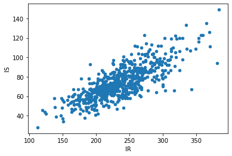

```python
relief.plot.scatter('IR', 'IS') # inhereted runners vs. inhereted runners scored
plt.show()
```

# Data Visualization with Matplotlib

Matplotlib is another popular plotting library in Python. There are two ways to plot in matplotlib:

1. pyplot style: create simple plots using the matplotlib.pyplot functions
2. object-oriented style: make more complex, detailed plots

For this project, use whichever style makes most sense and which is more comfortable

A great way to figure out which plot is best for you is to look through the documentation or the internet and find designs you like. Here are some helpful documentation links for your reference:

- [Matplotlib Pyplot Introduction and Functions](https://matplotlib.org/stable/api/_as_gen/matplotlib.pyplot.html#module-matplotlib.pyplot)
- [Matplotlib Pyplot Functions and Colormaps](https://matplotlib.org/stable/api/pyplot_summary.html)
- [Matplotlib User Guide](https://matplotlib.org/stable/tutorials/introductory/usage.html)
- [Tutorials on How To Use Matplotlib](https://matplotlib.org/stable/tutorials/index.html)
- [Examples of Matplotlib Plots](https://matplotlib.org/stable/gallery/index.html)
- [Named Colors in Matplotlib](https://matplotlib.org/2.0.2/examples/color/named_colors.html)
- [Linestyles in Matplotlib](https://matplotlib.org/2.0.2/examples/lines_bars_and_markers/line_styles_reference.html)

# Data Visualization with Matplotlib: Pyplot Example

Pyplot is good for creating figures that aren't split based on categories and do not need mutiple plots in the same visualization.

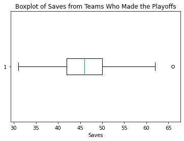

```python
plt.figure(figsize = (6, 4)) # define figure size
plt.boxplot(relief.loc[relief.Playoff == 'Yes', 'SV'], vert = False) # boxplot of the data, vertical = False
plt.xlabel('Saves')
plt.title('Boxplot of Saves from Teams Who Made the Playoffs')
plt.style.use('seaborn-colorblind') # choose a style you want to be applied to the graph
plt.show()
```

# Data Visualization with Matplotlib: Object-Oriented Example

In object-oriented matplotlib, the `plt.subplots()` function is used to create a grid of plots. `plt.subplots()` outputs a tuple containing the figure, which represents the grid as a whole, and the axes, which represent each individual plot in the grid.

Here are some examples:

`fig, (ax1, ax2) = plt.subplots(2)` [create 2 plots (by default it will make a 2x1 grid). Each plot will be accessed by `ax1` and `ax2`]

`fig, ax = plt.subplots(nrows = 2, ncols = 2)` [create 4 plots on a 2x2 grid. Each plot will be accessed by `ax[0]` through `ax[3]`]

There is an example in the next slide

# Data Visualization with Matplotlib: Object-Oriented Example

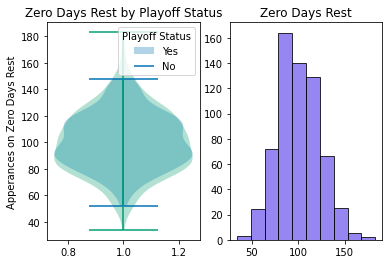

```python
fig, (ax1, ax2) = plt.subplots(nrows = 1, ncols = 2)
# 2 total plots, so that's why axes is being assigned to a tuple of length 2
ax1.violinplot(relief.loc[relief.Playoff == 'Yes', '0DR'])
ax1.violinplot(relief.loc[relief.Playoff == 'No', '0DR']) # plot a 2nd violin plot on the same graph
ax1.set_ylabel('Apperances on Zero Days Rest')
ax1.set_title('Zero Days Rest by Playoff Status')
ax1.legend(['Yes', 'No'], title = 'Playoff Status') # create a legend in the same order the plots were added
ax2.hist(relief['0DR'], color = 'mediumslateblue', alpha = 0.8, edgecolor = 'black')
# alpha is transparency and edgedolor sets the color around the histogram edges
ax2.set_title('Zero Days Rest')
plt.show()
```

# Data Visualization with Seaborn

```python
import seaborn as sns
```

Seaborn is another visualization library, but it is focused on making informative visualizations in only a small amount of code. Its style is similar to ggplot to some extent in that variables are mapped to certain plot aesthetics.

- Seaborn uses matplotlib to make the plots
- Seaborn sacrifices some customization abilities to make the usability easy

Here are some links to the documetation that are very helpful:

- [Overview of Seaborn Plotting Functions](https://seaborn.pydata.org/tutorial/function_overview.html)
- [Functions in Seaborn](https://seaborn.pydata.org/api.html)

# Data Visualization with Seaborn

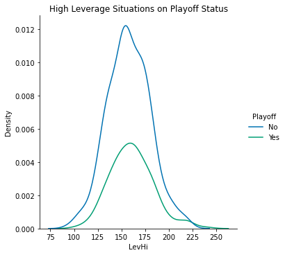

```python
sns.displot(data = relief, x = 'LevHi', hue = 'Playoff', kind = 'kde')
# map the LevHi variable to the x-axis, color to the playoff variable, and made it a kernel density estimate plot
plt.title('High Leverage Situations on Playoff Status')
plt.show()
```

# Data Visualization with Seaborn

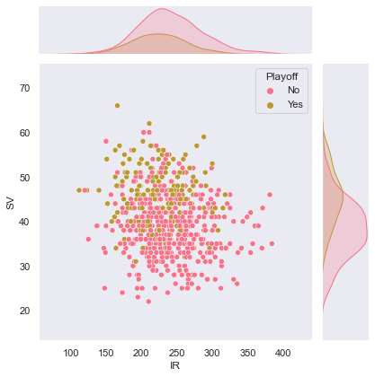

```python
sns.set_theme(style = 'dark', palette = 'husl') # set styles and color palettes
sns.jointplot(data = relief, x = 'IR', y = 'SV', hue = 'Playoff')
```

# Data Visualization with Seaborn

You can also set facet grids in seaborn, which create seperate plots based on different values of categorical variables.

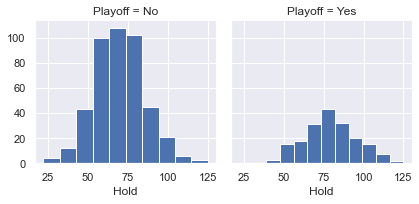

```python
sns.set_theme() # no arguments sets to the seaborn default theme
grid = sns.FacetGrid(relief, col = 'Playoff', margin_titles = True)
grid.map(plt.hist, 'Hold') # map matplotlib histograms to the grid, and plot the Hold variable
```

# Notes About Plot Creation For This Project

- Make your plots fun! Use different themes and colors to make your graphs look great!
- Include the playoff variable in most if not all of your visualizations, because that is what this project is about
- Look online and at the documentation for tutorials and examples of good plots

# GitHub For This Project

Starting with the assignment due next week (Week of July 25th), we will be uploading all of our work to the project GitHub instead of the project's Google Drive.

For those who are not familiar, GitHub is a website where data scientists can display their work by uploading their code, visualizations, and findings so that people can see your work.

There is a way to connect our project GitHub repository (folders/drives on GitHub are called repositories) to a folder on your computer so that when you make changes to code files on your computer, you can sync it to the GitHub repository (and vice versa sync the repository to your computer)! This is what we will be setting up today.

In order to sync folders on your computer to GitHub, you will need to open the shell (terminal) on your computer and type in Git commands

# Using Git

Git is already installed in mac and linux systems, but if you have a windows system you will need to install the latest version of Git from the internet. [Here is the link to Git for Windows](https://gitforwindows.org).

When you first install Git, you will have to configure it. Make sure that the email in your configured Git is the same one used for your GitHub account. To configure Git, execute the following commands in your shell (terminal):

- `git config --global user.name "[insert GitHub username here]"`
- `git config --global user.email "[insert GitHub email here]"`

To check whether you have Git already installed, type `git version` into the shell. If it returns the version, you have it. If it doesn't, you will need to install it.

In addition, you will need to create a GitHub account on github.com if you haven't already.

The following slides will be a tutorial on how to set up your GitHub account and link out project's GitHub to your computer

# Setting Up Our Project's GitHub Repository to Local Files on Your Computer

First, you will have to set up a SSH key for your computer on your GitHub account if you do not already have one. This allows GitHub to trust that the changes being made to the online repository from your computer are safe.

1. On github.com navigate to your profile picture > Settings > SSH and GPG Keys
2. In your shell, type `ssh-keygen -t ed25519 -C "youremail@web.com"` to generate a SSH Key, using the email address associated with your GitHub account. If you are the only person that uses your computer, I would reccommend not including a passcode. To do this, leave "enter passphrase" blank by hitting `enter` twice.
3. Next, you will need to navigate to the .ssh folder on your computer using the shell. To do this, type `cd .ssh` in your shell (this **c**hanges the working **d**irecotry to the .ssh folder). If you then type `ls` into the shell, it will list off the items in your current working directory. You should see an item that is named `id_ed25519.pub`.
4. Next, type `cat id_ed25519.pub` (cat means print like cat() in R) to print out your SSH key. Copy the SSH key.
5. Go back onto github.com, hit `New SSH Key`, and paste the SSH key into the Key box. Title the SSH key to the name of your computer and add it to your account.

# Setting Up Our Project's GitHub Repository to Local Files on Your Computer

The next step is to clone (add) the repository to the folder you want it in on your computer. To do this, use `cd` in the shell to navigate to the directory (folder) on your computer you would like to place the repository in. I would suggest having your file system open and using `tab` completion so that you can navigate to the correct folder and `ls` to get a reminder of what is in the current folder.

Once your directory is set to the one you want the repository in (use `pwd` in the shell to check your present (current) working directory):

1. Go to the repository on GitHUb and select Code > SSH > *copy* the SSH GitHub repository name
2. In the shell, type `git clone [SSH GitHub repository name]`

The online reposiotry and the folder on your computer are now synced!

# Important Git Commands for Syncing the Two Repositories

Before uploading and dowloanding files to and from the GitHub repository, make sure your current directory is the repository folder on your computer, or else you will encounter errors.

- `git status`: tells you the current status of your repository. If you are new to Git, it really helps to type `git status` after every other git command, it will help to understand exactly what is happening.
- `git pull`: takes the current version of the repository on GitHub and syncs it to your local repository (the folder of the repository on your computer). You should always use `git pull` before adding anything new to the repository so there are never any potential sync conflicts after other people add files.
- `git add [filename.file OR . (all files)]`: adds new files/changes made to the staging area (deems those files ready to be committed (added) to the repository)
- `git commit -m "description"`: commits (makes the changes) to the repository and adds description of the changes that were made (i.e. "added the code file for my matplotlib graphs")
- `git push`: takes the changes that were made on your local reposiotry and syncs them to the GitHub repository online so that everyone can see

# Notes About Git/GitHub

- There is more to Git like working with branches, but that is beyond the scope of this project (I think)
- Always make sure to use the `git pull` command to have the latest version of the repository on your computer

Steps you should take when:

1. You want update your local repository by syncing it with the project's online repository: `git pull`
2. You want update the project's online repository by syncing it with your local repository: `git add filename.file OR git add .` $\to$ `git commit -m "description"` $\to$ `git push`

# Looking Ahead for Next Week

What will be due:

- 5 total visualizations of your data set which must consist of:
  - At least 2 matplotlib and 2 seaborn visualizations
  - At least 1 visualization with multiple plots
  - At least 4 of the 5 must use a style/theme other than the base matplotlib and seaborn styles
- Research at least 2 machine learning algorithims that would work well for predicting if a team made the playoffs and write them down in your code file
- Make a GitHub account and link our GitHub repository to your computer
- Fill out the When2Meet form for next week

Take care and have a great rest of your week!`